## Introduction

I wanted to do a follow-up on my posts about Texas high school UIL academic competitions where I evaluate the relationship between the school performance in those competitions with school-wide SAT and ACT scores. In my introduction to that series, I stated the following: *School-wide … scores on state- and national-standardized tests (e.g. the Standardized SAT) certainly are the most common measure of academic strength, but I think rankings by academic competitions may be more indicative.*

In a sense, I implied that the academic UIL scores may not correspond well, or at all, with standardized test scores. So let’s set out to see what we can prove (one way or the other).

## Data Collection

To my delight, the [Texas Education Agency’s website](https://tea.texas.gov) publishes Texas high school SAT and [ACT](https://www.act.org/) scores for the years 2011 through 2015. (For those who may not be familiar with these tests, which, strangely don’t really have non-abbreviated names, they are the two most popular standardized tests used for college admission in the United States.) The task of scraping from this source is a perfect use-case for the super-handy `{xml2}` and `{rvest}` packages, as well the well-knwon `{stringr}` and `{purrr}` packages in the `{tidyverse}`.

```r
library("tidyverse")
library("rlang")
library("teplot")
```

```r
urls_tea <-
  "https://tea.texas.gov/acctres/sat_act_index.html" %>%
  xml2::read_html() %>%
  rvest::html_nodes(xpath = "//tr //td //a") %>%
  rvest::html_attr("href") %>%
  str_subset("^\\/acctres\\/[:alpha:]{3}_[Cc]ampus_[Dd]ata")
urls_tea
```

[1] “/acctres/sat_campus_data_class_2015/” [2] “/acctres/act_campus_data_class_2015/” [3] “/acctres/sat_campus_data_class_2014/” [4] “/acctres/act_campus_data_class_2014/” [5] “/acctres/SAT_Campus_Data_class_2013/” [6] “/acctres/ACT_Campus_Data_class_2013/” [7] “/acctres/SAT_Campus_Data_class_2012/” [8] “/acctres/ACT_Campus_Data_class_2012/” [9] “/acctres/SAT_Campus_Data_class_2011/” [10] “/acctres/ACT_Campus_Data_class_2011/”

```r
create_path_dl_tea <-
  function(url_suffix = NULL, dir = "data-raw", ext = "csv") {
    if(!dir.exists(dir)) {
       dir.create(dir)
    }
    url_suffix %>%
      str_remove_all("acctres|\\/") %>%
      paste0(".", ext) %>%
      file.path(dir, .)
  }
```

```r
# NOTE(s):
# + `urls_tea_dl` is actually the same as `url_tea` because `purrr::walk()` returns its first argument.
# + `mode = "wb"` is important! Otherwise, the downloaded files have empty lines every other line
# (due to the way that CR and LFs are handled.
urls_tea_dl <-
  urls_tea %>%
  walk(
    ~download.file(
      url = paste0("https://tea.texas.gov/", .x),
      destfile = create_path_dl_tea(url_suffix = .x),
      mode = "wb"
    )
  )
```

Next, I bind the data from all of the downloaded files together and do some cleaning.

One relatively significant choice that I make is to only include the data for the school-wide level (via the `"All Students"` filtering criteria), although data for different demographics within each school is provided.

Additionally, there are some details of each of the standardized tests of which the reader shoold be made aware. The SAT has `math`, `reading`, and `writing` sections, each having minimum and maximum scores of 200 and 800, meaning that the `total` can range from 600 to 2400. The ACT has `math`, `reading`, `english`, and `science` sections, each having a minimum and maximum score of 1 and 36, combined for a single `compos` score also ranging from 1 to 36. To eliminate duplicate columns representing the same underlying “thing”. I don’t distinguish the `math` and `reading` section scores for each test in separate columns, I rename the ACT’s `compos` score to `total`, following the convention used for the SAT’s cumulative score. The other sections–`writing` for the SAT and `english` and `science` for the ACT– are not really analogous to sections in the other test, so they are filled with `NA`s appropriately.

```r
schools_tea <-
  urls_tea %>%
  create_path_dl_tea() %>%
  tibble(path = .) %>%
  mutate(
    test = stringr::str_extract(path, "([Ss][Aa][Tt])|([Aa][Cc][Tt])") %>% str_to_upper(),
    year = stringr::str_extract(path, "[:digit:]+") %>% as.integer()
  ) %>%
  mutate(contents =
           purrr::map2(path, test,
                       # ~import_tea_data(.x, .y)
                       ~ {
                         .x %>%
                           readr::read_csv() %>%
                           rename_all(funs(tolower)) %>%
                           filter(group == "All Students") %>%
                           select(
                             matches(
                               "name$|math|reading|writing|total|english|science|compos"
                             )
                           )
                       })) %>%
  unnest() %>%
  select(-path) %>%
  mutate_at(vars(total), funs(ifelse(test == "ACT", compos, .))) %>%
  select(-compos) %>%
  select(-total, everything(), total) %>%
  rename(school = campname,
         district = distname,
         county = cntyname,
         city = regnname) %>%
  mutate_if(is.character, funs(str_replace_all(., "=|\"", ""))) %>%
  mutate_at(vars(matches("school|district|city|county")), funs(toupper)) %>%
  mutate_at(vars(county), funs(str_remove_all(., "\\s+COUNTY"))) %>%
  mutate_at(vars(school), funs(str_remove_all(., "[H]\\s*[S]$") %>% str_trim())) %>%
  # NOTE: This is (try to) to resolve duplicates in raw data.
  # group_by_at(vars(matches("test|year|school|district|county|city"))) %>%
  # summarise_all(funs(max(., na.rm = TRUE))) %>%
  # ungroup() %>%
  arrange(test, year, school)
schools_tea
```

[output not shown]

### Data Exploration

First, before evaluating the primary concern at hand–the relationship between the academic UIL scores (accessible in data that I collected and cleaned for my series of posts analyzing the UIL data) and the SAT/ACT scores (available in the `schools_tea` data created above)–I first want to verify that there is some non-trivial relationship among the scores for a given school on a given test across years. (I would be suprised if this were not shown to be true.)

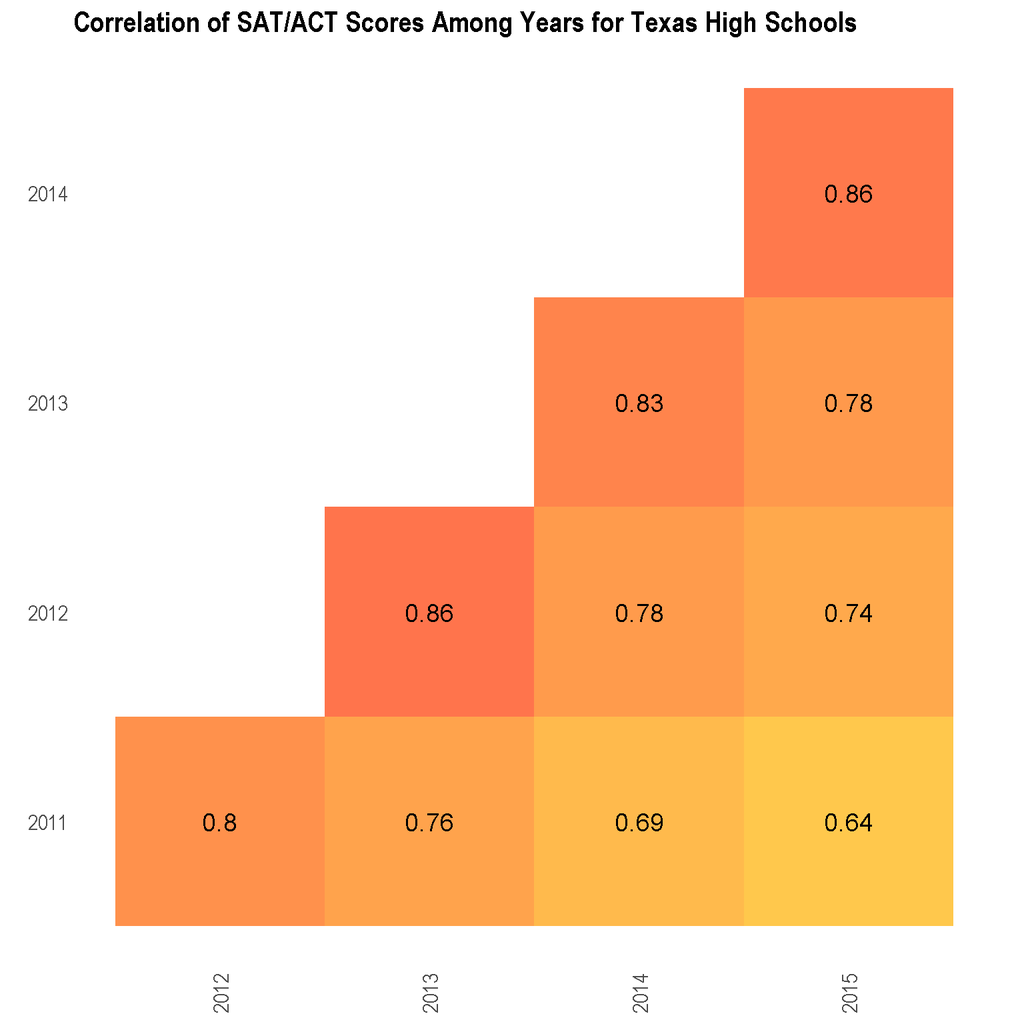

```r
schools_tea_cors_byyear <-
  schools_tea %>%
  distinct(test, year, school, .keep_all = TRUE) %>%
  filter(!is.na(total)) %>%
  unite(test_school, test, school) %>%
  widyr::pairwise_cor(
    feature = test_school,
    item = year,
    value = total
  ) %>%
  rename(year1 = item1, year2 = item2, cor = correlation)
schools_tea_cors_byyear %>%
  filter(year1 <= year2)
```

As expected, there is some storng correlations among the years for school-wide scores on these tests.

Ok, now let’s bring in the “cleaned” school data (`schools_uil`) that I collected and cleaned my UIL analysis.

```r
schools_uil <-
  file.path("data", "schools_uil.csv") %>%
  readr::read_csv()
schools_uil
```

Now let’s review this data set to see if year-to-year correlations also exist with it.

Importantly, some choice about how to quantify performance needs to be made. As I discussed in my long-form series of posts exploring the UIL academic data, the evaluation of performance is somewhat subjective. Should we use number of times a school advanced to the next level of competition in a given year? (Note that there are three competition levels–`District`, `Region`, and `State`.) What about the number the number of other schools it “defeated” in head-to-head competitions? In that separate analysis, I made the choice to use the percentile rank (`prnk`) of the school’s placings across all competition levels for a given competition type (`comp`). I beleive this measure bests represent a school’s quality of performance (where a higher value indicates better performance). As I stated there when explaining my choice to use percent rank for identifying “dominant” individual“, *”I choose to use percent rank–which is a always a value between 0 and 1–because it inherently accounts for the wide range of number of competitors across all competitions. (For this context, a percent rank of 1 corresponds to the highest score in a given competition, and, conversely, a value of 0 corresponds to the lowest score.)"*

Aside from this important choice regarding performance evaluation in academic UIL competitions, note that I treat the competition type (`comp`) in `schools_uil` as analogous to the `test` variable indicating SAT or ACT score in the `schools_tea` data set. For those who have not read through my UIL analysis, note that scores for five different competition types was collected–`Calculator Applications`, `Computer Science`, `Mathematics`, `Number Sense`, and `Science`.

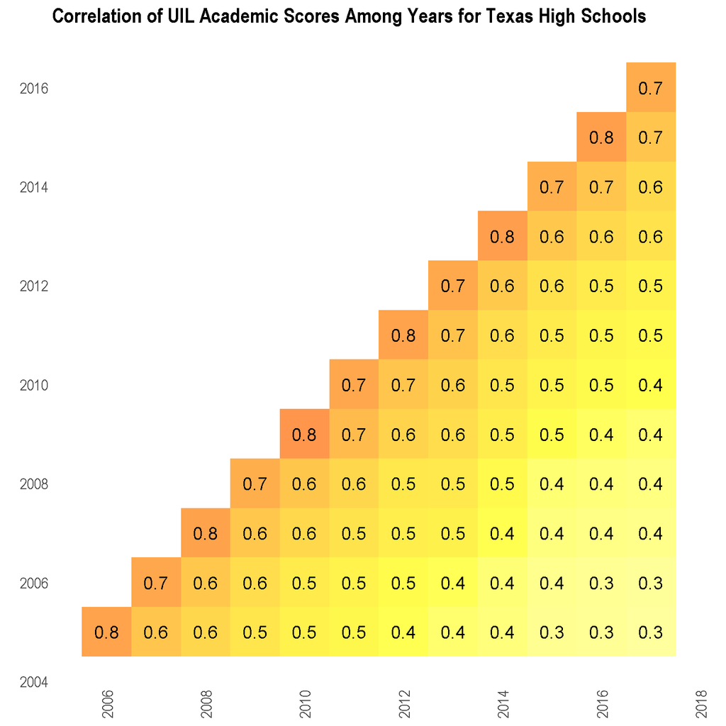

```r
schools_uil_cors_byyear <-
  schools_uil %>%
  select(year, school, city, comp, prnk) %>%
  group_by(year, school, city, comp) %>%
  summarise(prnk_sum = sum(prnk, na.rm = TRUE)) %>%
  ungroup() %>%
  unite(comp_school, comp, school) %>%
  widyr::pairwise_cor(
    feature = comp_school,
    item = year,
    value = prnk_sum
  ) %>%
  rename(year1 = item1, year2 = item2, cor = correlation)

schools_uil_cors_byyear %>%
  filter(year1 <= year2)
```

We can see that correlations among years do exist, as we would expect. The strength of the correlations decrease for years that are farther apart, which is also what we might expect.

### Aside: Fuzzy Joining

An important thing to keep in mind is that the acadmeic UIL data was scraped from a different website–https://www.hpscience.net/ (which was the only site that I found to have the academic competition scores)–than that used to collect the SAT and ACT scores here.

In its raw form, the UIL data is much “more unclean” than the data from the TEA website, and some/many of the names are inconsistent. In fact, the rigor involved in cleaning the UIL data obliged be to completely hide it from the reader in my write-ups on the topic. Nonetheless, I was able to eliminate much of the “self-inconsistency” of the UIL data and create a suitable data set to use as one of the basis for that long-form analysis.

However, given this context–in which I am comparing data from two different data sources–the reality is that there are more than a few differences in the names of schools, so joining the data from the two different sources is tricky. To aid in my experimentation with “fuzzy joining”, I created a function–`join_fuzzily()`– to serve as a wrapper for the `stringdist_*_join()` functions provided by the `{fuzzyjoin}` package. With this function, I was able to evaluate different values for `max_dist` and different join columns to make a judgement regarding the quality of joins–primarily via counts of joined and unjoined rows using the `summarise_join_stats()` function from my personal `{tetidy}` package–to make a decision on how I should join the UIL and SAT/ACT school data. [^1]

```r
join_fuzzily <-
  function(x = NULL,
           y = NULL,
           how = "inner",
           max_dist = 0,
           cols_join = "school",
           copy = FALSE,
           suffix_x = "_x",
           suffix_y = "_y") {

    f <- sprintf("fuzzyjoin::stringdist_%s_join", how)

    ret <-
      teproj::do_call_with(f, list(x = x, y = y, by = cols_join, max_dist = max_dist))

    ret <-
      ret %>%
      rename_at(vars(ends_with(".x")), funs(gsub("\\.x", suffix_x, .))) %>%
      rename_at(vars(ends_with(".y")), funs(gsub("\\.y", suffix_y, .)))

    if(copy) {
      cols_join_y <- quo_name(paste0(cols_join, suffix_y))
      ret <-
        ret %>%
        left_join(y %>% mutate(!!!sym(cols_join_y) := !!!sym(cols_join)), by = cols_join)
    }
    ret
  }
```

```r
schools_uil_distinct <-
  schools_uil %>%
  distinct(school, city)
```

```r
summ_schools_join_fuzzy_1 <-
  schools_tea %>%
  join_fuzzily(
    schools_uil_distinct,
    how = "full",
    max_dist = 0,
    cols_join = c("school"),
    suffix_x = "_tea",
    suffix_y = "_uil"
  ) %>%
  tetidy::summarise_join_stats(school_uil, school_tea) %>%
  select(-x, -y) %>%
  gather(metric, value)
summ_schools_join_fuzzy_1
```

[output not shown]

```r
# NOTE: Use a full join to get more informative output from `tetidy::summarise_join_math()`.
summ_schools_join_fuzzy_2 <-
  schools_tea %>%
  unite(school_city, school, city, remove = FALSE) %>%
  join_fuzzily(
    schools_uil_distinct %>%
      unite(school_city, school, city, remove = FALSE),
    how = "full",
    # how = "left",
    max_dist = 0,
    cols_join = c("school_city"),
    suffix_x = "_tea",
    suffix_y = "_uil"
  ) %>%
  tetidy::summarise_join_stats(school_city_uil, school_city_tea) %>%
  select(-x, -y) %>%
  gather(metric, value)
summ_schools_join_fuzzy_2
```

[output not shown]

### Relationship between Academic UIL Performance and SAT/ACT scores.

So, at this point, having decided how to join the data, I have set myself up to do that which I set out to do–evaluate the relationship between the academic UIL competition scores and the national SAT/ACT scores.

In order to put the two sets of data on “equal grounds”, I only evaluate math scores. In particular, I filter `comp` in the UIL data to just the mathematically-based competitions–`Calculator Applications`, `Mathematics`, and `Number Sense`–excluding `Science` and `Computer Science`. And, for the SAT/ACT data, I select only the `math` score, which is available fore both tests, excluding the `total` and `reading` scores also available for each and the `writing`, `english`, and `science` scores available for one or the other. (Perhaps the ACT’s `science` score could be compared to the `Science` UIL scores, but I choose not to do so here.)

```r
schools_uil_math <-
  schools_uil %>%
  filter(str_detect(comp, "Calculator|Math|Number")) %>%
  group_by(year, school, city) %>%
  summarise(prnk_sum = sum(prnk, na.rm = TRUE)) %>%
  ungroup() %>%
  # NOTE: "Renormalize" `prnk_sum`.
  mutate(math_prnk = percent_rank(prnk_sum)) %>%
  select(-prnk_sum)
schools_uil_math
```

```r
schools_tea_math <-
  schools_tea %>%
  select(test, year, school, city, math) %>%
  filter(!is.na(math)) %>%
  group_by(test) %>%
  mutate(math_prnk = percent_rank(math)) %>%
  ungroup() %>%
  group_by(year, school, city) %>%
  summarise_at(vars(math_prnk), funs(mean(., na.rm = TRUE))) %>%
  ungroup()
schools_tea_math
```

```r
schools_join_math <-
  schools_tea_math %>%
  rename_at(vars(matches("^math")), funs(paste0("tea_", .))) %>%
  inner_join(schools_uil_math %>%
             rename_at(vars(matches("^math")), funs(paste0("uil_", .))),
           by = c("year", "school", "city")) %>%
  select(year, school, city, matches("math"))
schools_join_math
```

```r
schools_join_math_cors <-
  schools_join_math %>%
  select(-year) %>%
  select_if(is.numeric) %>%
  corrr::correlate()
schools_join_math_cors
```

[output not shown]

So, this correlation value–0.362937–seems fairly low. At face value, it certainly does not provide any basis to claim that schools that do well in the academic UIL competitions also do well with SAT/ACT tests. However, perhaps if I used a different methodology, the result would be different. Other metrics used to quantify academic UIL performance could be tested in some kind of sensitivity analysis.

While I won’t do any kind of rigorous second evaulation here, I do want to try to quantify the impact of the “missing” data dropped due to mismatched school names. If all possible data had been used, would the final correlation value increased (or decreased)? A direct answer to this question is impossible, but we can evaluate the difference in the year-to-year correlations of scores from the schools that are joined with the correlations calculated for all in “unjoined” `schools_tea` and `schools_uil` data sets. If we find that there are large discrepancies (one way or the other), then we may have some reason to believe that the 0.362937 number found above is misleading.

```r
schools_postjoin_math_tidy <-
  schools_join_math %>%
  unite(school_city, school, city) %>%
  gather(metric, value, matches("prnk"))
```

```r
pairwise_cor_f1 <-
  function(data = NULL, which = c("tea", "uil")) {
    which <- match.arg(which)
    data %>%
      filter(metric %>% str_detect(which)) %>%
      filter_at(vars(value), all_vars(!is.nan(.))) %>%
      widyr::pairwise_cor(
        feature = school_city,
        item = year,
        value = value
      ) %>%
      rename(year1 = item1, year2 = item2, cor = correlation) %>%
      mutate(source = which %>% toupper())
  }

pairwise_cor_f2 <-
  function(data = NULL, which = c("tea", "uil")) {
    which <- match.arg(which)
    col <-
      data %>%
      names() %>%
      str_subset("math")
    data %>%
      unite(school_city, school, city) %>%
      rename(value = !!rlang::sym(col)) %>%
      mutate(source = which %>% toupper()) %>%
      widyr::pairwise_cor(
        feature = school_city,
        item = year,
        value = value
      ) %>%
      rename(year1 = item1, year2 = item2, cor = correlation) %>%
      mutate(source = which %>% toupper())
  }
```

```r
schools_postjoin_math_cors_byyear <-
  bind_rows(
    schools_postjoin_math_tidy %>%
      pairwise_cor_f1("tea"),
    schools_postjoin_math_tidy %>%
      pairwise_cor_f1("uil")
  )

schools_prejoin_math_cors_byyear <-
  bind_rows(
    schools_tea_math %>%
      pairwise_cor_f2("tea"),
    schools_uil_math %>%
      filter(year >= 2011, year <= 2015) %>%
      pairwise_cor_f2("uil")
  )

schools_math_cors_byyear_diffs <-
  schools_postjoin_math_cors_byyear %>%
  inner_join(schools_prejoin_math_cors_byyear,
             by = c("year1", "year2", "source"),
             suffix = c("_join", "_unjoin")) %>%
  mutate(cor_diff = cor_join - cor_unjoin)
```

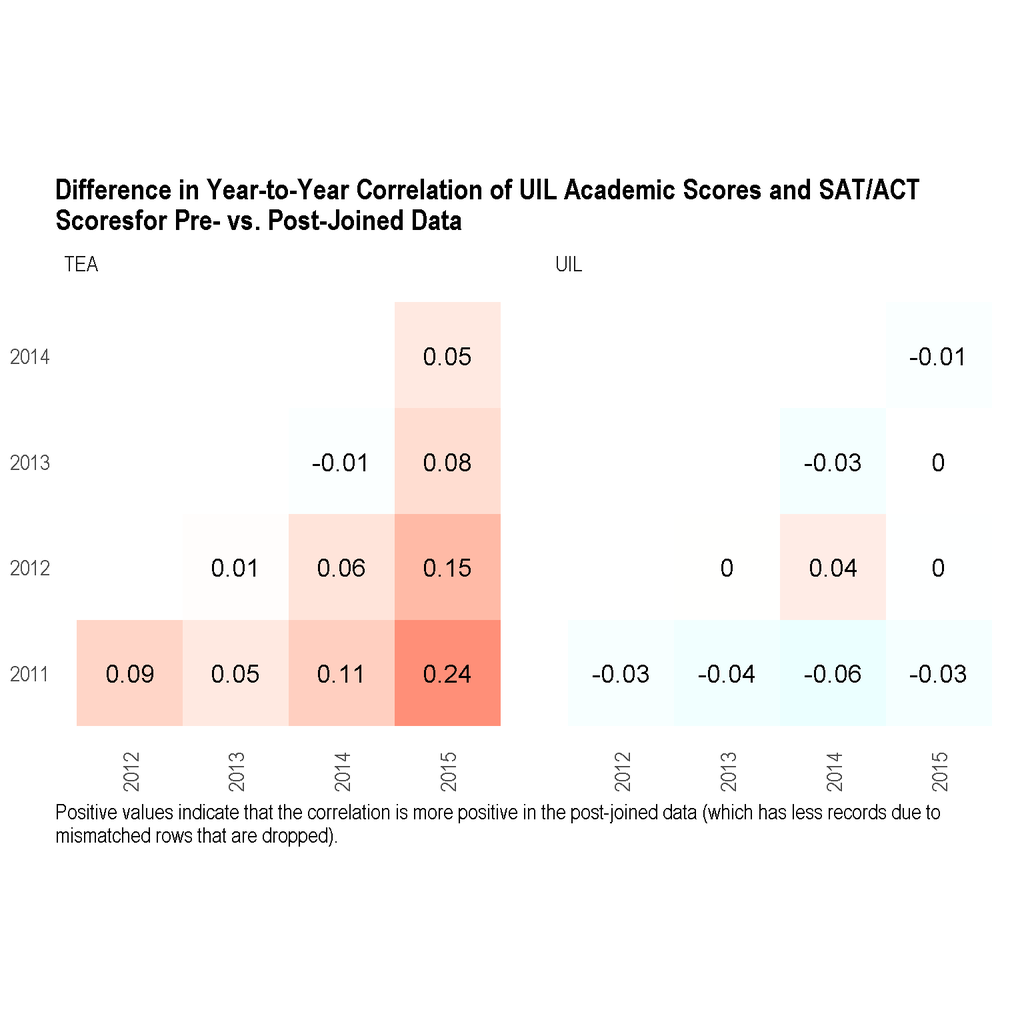

```r
schools_math_cors_byyear_diffs_wide <-
  schools_math_cors_byyear_diffs %>%
  filter(year1 <= year2) %>%
  select(-matches("join$")) %>%
  unite(year_pair, year1, year2) %>%
  spread(source, cor_diff)
schools_math_cors_byyear_diffs_wide
```

Note that the correlations in the joined data are a bit “stronger”–in the sense that they are more positive–among the TEA SAT/ACT-related data, although not in any kind of magnificent way. Additionally, the differences for the UIL data are trivial. Thus, we might say that the additional data that could have possibly increased (or decreased) the correlation value found–0.362937–would not have changed much at all.

## Conclusion

So, my initial inclination (stated in the introduction to my series of posts on the academic UIL competitions) seems correct–there is no significant relationship between Texas high school academic competition scores and standardized test scores (for math).

[^1]: Check out my post on the “DRY” principle and its application to `R` packages.